# The Elo method in chess

Maroan Mejric

**Elo method** was coined by the physics professor and excellent chess player Arpad Elo. In 1970, FIDE, the World Chess Federation, agreed to adopt the Elo Rating System.

Suppose that players $i$ and $j$ match. Let $s_{i,j}$ be the **actual score** of $i$ in the match against $j$ (1 if $i$ wins, 0 if $i$ loses, 0.5 if there is a draw), with $s_{j,i} = 1 - s_{i,j}$. Let $\mu_{i,j}$ be the **expected score** of $i$ in the match against $j$:

$$\mu_{i,j} = \frac{1}{1 + 10^{-(r_i - r_j) / \zeta}}$$

with $r_i$ and $r_j$ the ratings of $i$ and $j$ before the match and $\zeta$ a constant, with $\mu_{j,i} = 1 - \mu_{i,j}$. Initially all ratings are equal to 0 and after a match the ratings are updated as follows:

$$\begin{array}{lll}
r_{i} & \leftarrow & r_i + \kappa (s_{i,j} - \mu_{i,j})
\\
r_j & \leftarrow & r_j + \kappa (s_{j,i} - \mu_{j,i})
\end{array}$$

where $\kappa$ is a constant.

## Dataset

A CSV with outcomes of 65053 distinct chess games (White, Black and Score). The possible values for Score represent the three possible outcomes of a chess game (1 = White wins, 0.5 = draw, 0 = Black wins).

```r
library(tidyverse)

games = read_csv("data.csv")
games
```

```
## # A tibble: 65,053 × 3
##    White Black Score
##    <dbl> <dbl> <dbl>
##  1    73  1246   0.5
##  2    73  5097   0.5
##  3    73  5104   0.5
##  4    73  7321   1
##  5    73  7375   0.5
##  6    88  1033   0.5
##  7    88  1860   1
##  8    88  4858   1
##  9   154  3377   0
## 10   158  8059   1
## # ℹ 65,043 more rows
```

```r
# number of games and of players
nrow(games)
```

```
## [1] 65053
```

```r
n_distinct(c(games$White, games$Black))
```

```
## [1] 7301
```

## 1. Has the White an advantage over the Black?

The mean score of the White is the fraction of points won by the White players over all games. If there were no first-mover advantage it would be 0.5:

```r
# distribution of outcomes
games |>
  count(Score) |>
  mutate(p = n / sum(n))
```

```
## # A tibble: 3 × 3
##   Score     n     p
##   <dbl> <int> <dbl>
## 1   0   15224 0.234
## 2   0.5 28666 0.441
## 3   1   21163 0.325
```

```r
# mean score of White
mean(games$Score)
```

```
## [1] 0.5456474
```

The White wins more often than the Black (and the mean score of the White is above 0.5), hence there is a first-mover advantage.

## 2. Compute the player point rating

The point rating of a player is the sum of the scores of the player over all the games played. In a game, the White gets `Score` points and the Black gets `1 - Score` points. We build a table with one row per player and game and then we sum the points of each player:

```r
# one row per player and game
played = bind_rows(
  games |> transmute(player = White, score = Score),
  games |> transmute(player = Black, score = 1 - Score)
)

# point rating and number of games of each player
points =
  played |>
  group_by(player) |>
  summarise(games = n(), points = sum(score)) |>
  arrange(desc(points))

points
```

```
## # A tibble: 7,301 × 3
##    player games points
##     <dbl> <int>  <dbl>
##  1   4037   272   168.
##  2   1286   270   166.
##  3   4850   280   159
##  4   1594   276   156
##  5     64   258   155
##  6   1098   252   154.
##  7    391   255   152
##  8   1512   257   142.
##  9   5050   216   140.
## 10   2283   211   134
## # ℹ 7,291 more rows
```

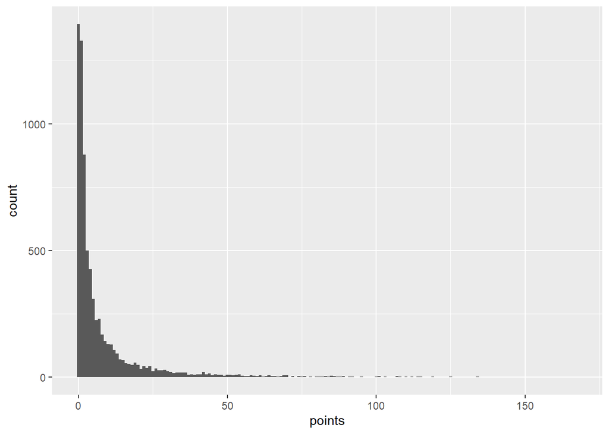

```r
# distribution of points
ggplot(points, aes(points)) +
  geom_histogram(binwidth = 1)
```

```r
summary(points$points)
```

```
##    Min. 1st Qu.  Median    Mean 3rd Qu.    Max.
##    0.00    1.00    3.00    8.91    9.00  167.50
```

The distribution of points is highly right skewed: most players have few points and few players have many points. This is because the point rating accumulates with the number of games played, and most players played few games while few players played many games:

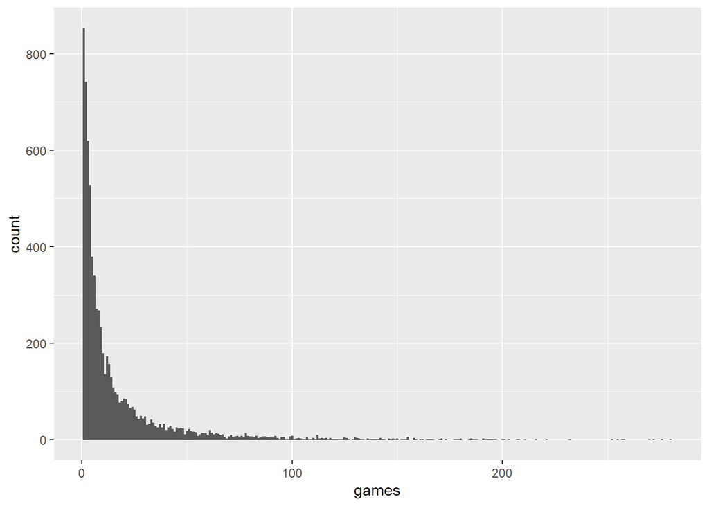

```r
ggplot(points, aes(games)) +
  geom_histogram(binwidth = 1)
```

```r
summary(points$games)
```

```
##    Min. 1st Qu.  Median    Mean 3rd Qu.    Max.
##    1.00    3.00    7.00   17.82   20.00  280.00
```

## 3. The sum of all Elo ratings is always 0

Initially all ratings are 0, hence their sum is 0. We show that a match between $i$ and $j$ does not change the sum of ratings. The sum of the changes of the two ratings is:

$$\kappa (s_{i,j} - \mu_{i,j}) + \kappa (s_{j,i} - \mu_{j,i}) =
\kappa \left[ (s_{i,j} + s_{j,i}) - (\mu_{i,j} + \mu_{j,i}) \right] =
\kappa (1 - 1) = 0$$

since $s_{i,j} + s_{j,i} = 1$ and $\mu_{i,j} + \mu_{j,i} = 1$. The ratings of the other players do not change. Hence, by induction on the number of matches, the sum of all ratings is always 0.

## 4. Compute the player Elo rating

We set $\zeta = 400$ and $\kappa = 25$. The games are processed one at a time in the order in which they appear in the dataset, since the rating before a match depends on the previous matches. We take advantage of the 0-sum property: the change of rating of the Black is the opposite of the change of rating of the White, hence we compute only one expected score and one update per game.

```r
# logistic function (expected score)
logistic = function(x, z = 400) {
  return(1 / (1 + 10^(-x / z)))
}

zeta = 400
kappa = 25

# player ids
white = games$White
black = games$Black
score = games$Score

# all ratings start at 0 (one for each player id)
elo = rep(0, max(c(white, black)))

# process the games in order
for (g in 1:nrow(games)) {
  i = white[g]
  j = black[g]
  # expected score of White
  mu = logistic(elo[i] - elo[j], zeta)
  # update of White; the update of Black is the opposite (0-sum property)
  delta = kappa * (score[g] - mu)
  elo[i] = elo[i] + delta
  elo[j] = elo[j] - delta
}

# Elo ratings of the players in the dataset
ratings =
  points |>
  mutate(elo = elo[player]) |>
  arrange(desc(elo))

ratings
```

```
## # A tibble: 7,301 × 4
##    player games points   elo
##     <dbl> <int>  <dbl> <dbl>
##  1   7848   185  114.   327.
##  2   3344   200  130.   274.
##  3   7715   129   76.5  271.
##  4   2295   162   99.5  271.
##  5    158   148   93.5  270.
##  6   8121   154  101    261.
##  7   2479   165  110.   256.
##  8   2581   158  100    246.
##  9   8287   192  122    245.
## 10     64   258  155    238.
## # ℹ 7,291 more rows
```

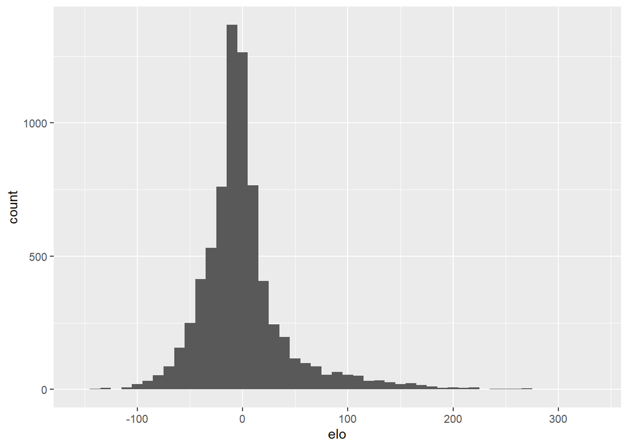

```r
# distribution of Elo ratings
ggplot(ratings, aes(elo)) +
  geom_histogram(binwidth = 10)
```

```r
summary(ratings$elo)
```

```
##     Min.  1st Qu.   Median     Mean  3rd Qu.     Max.
## -146.456  -22.873   -6.005    0.000   12.476  326.950
```

The distribution of Elo ratings is centered on 0 and has both a negative and a positive side (the mean is 0, the median is close to 0), while the distribution of points is right skewed and starts at 0. The reason is that the Elo rating does not accumulate with the number of games: a player gains rating only when it performs better than expected and loses rating when it performs worse than expected, hence a player with many games is not advantaged by the number of games. Moreover, every gain of a player is a loss of the same size for its opponent, so that the ratings are balanced around 0.

Finally, we verify the 0-sum property for the Elo ratings:

```r
sum(elo)
```

```
## [1] 9.476309e-13
```

## 5. Are point and Elo ratings correlated?

```r
cor(ratings$points, ratings$elo)
```

```
## [1] 0.7198872
```

```r
cor(ratings$points, ratings$elo, method = "spearman")
```

```
## [1] 0.406949
```

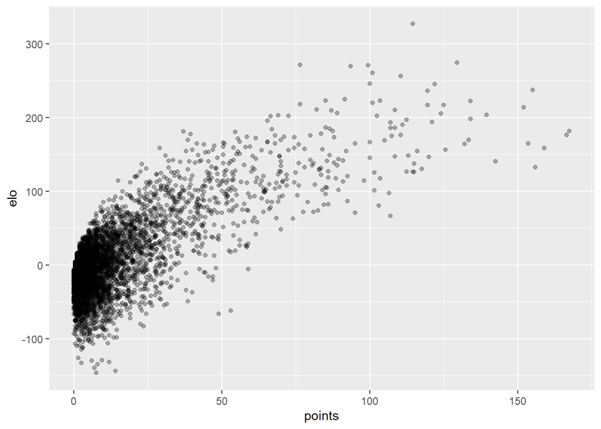

```r
ggplot(ratings, aes(points, elo)) +
  geom_point(alpha = 0.3)
```

The two ratings are positively correlated, but the correlation is moderate and the rank correlation (Spearman) is low: the two ratings order the players quite differently. Let’s check the overlap of the top players:

```r
k = 20
top_points = head(arrange(ratings, desc(points)), k)$player
top_elo = head(arrange(ratings, desc(elo)), k)$player

# players in both top lists
intersect(top_points, top_elo)
```

```
## [1]   64  391 2283 3344 5942 8287
```

```r
length(intersect(top_points, top_elo)) / k
```

```
## [1] 0.3
```

```r
# top-k Elo players
head(arrange(ratings, desc(elo)), k)
```

```
## # A tibble: 20 × 4
##    player games points   elo
##     <dbl> <int>  <dbl> <dbl>
##  1   7848   185  114.   327.
##  2   3344   200  130.   274.
##  3   7715   129   76.5  271.
##  4   2295   162   99.5  271.
##  5    158   148   93.5  270.
##  6   8121   154  101    261.
##  7   2479   165  110.   256.
##  8   2581   158  100    246.
##  9   8287   192  122    245.
## 10     64   258  155    238.
## 11   7953   207  120.   236.
## 12   5342   150   91.5  225.
## 13   7593   141   85    223.
## 14   7616   177  104.   223.
## 15   2283   211  134    222.
## 16   3887   180  101    220.
## 17   1158   123   76.5  218.
## 18   5942   191  125    217.
## 19   5531   195  120.   217.
## 20    391   255  152    214.
```

```r
# top-k point players
head(arrange(ratings, desc(points)), k)
```

```
## # A tibble: 20 × 4
##    player games points   elo
##     <dbl> <int>  <dbl> <dbl>
##  1   4037   272   168.  181.
##  2   1286   270   166.  176.
##  3   4850   280   159   158.
##  4   1594   276   156   132.
##  5     64   258   155   238.
##  6   1098   252   154.  164.
##  7    391   255   152   214.
##  8   1512   257   142.  140.
##  9   5050   216   140.  203.
## 10   2283   211   134   222.
## 11   2599   208   134   198.
## 12   1397   221   134.  169.
## 13   4171   232   132   164.
## 14   3344   200   130.  274.
## 15   6586   191   126.  156.
## 16   5942   191   125   217.
## 17   7638   211   124   205.
## 18   8287   192   122   245.
## 19   6691   193   121   194.
## 20   6270   203   120   147.
```

The top point players are only partially overlapping with the top Elo players: many top point players have a lot of points because they played many games, not because they are strong.

## 6. The effect of the number of played games

```r
cor(ratings$games, ratings$points)
```

```
## [1] 0.9900841
```

```r
cor(ratings$games, ratings$elo)
```

```
## [1] 0.6387939
```

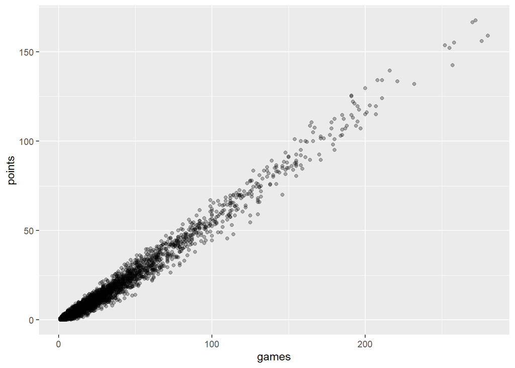

```r
ggplot(ratings, aes(games, points)) +
  geom_point(alpha = 0.3)
```

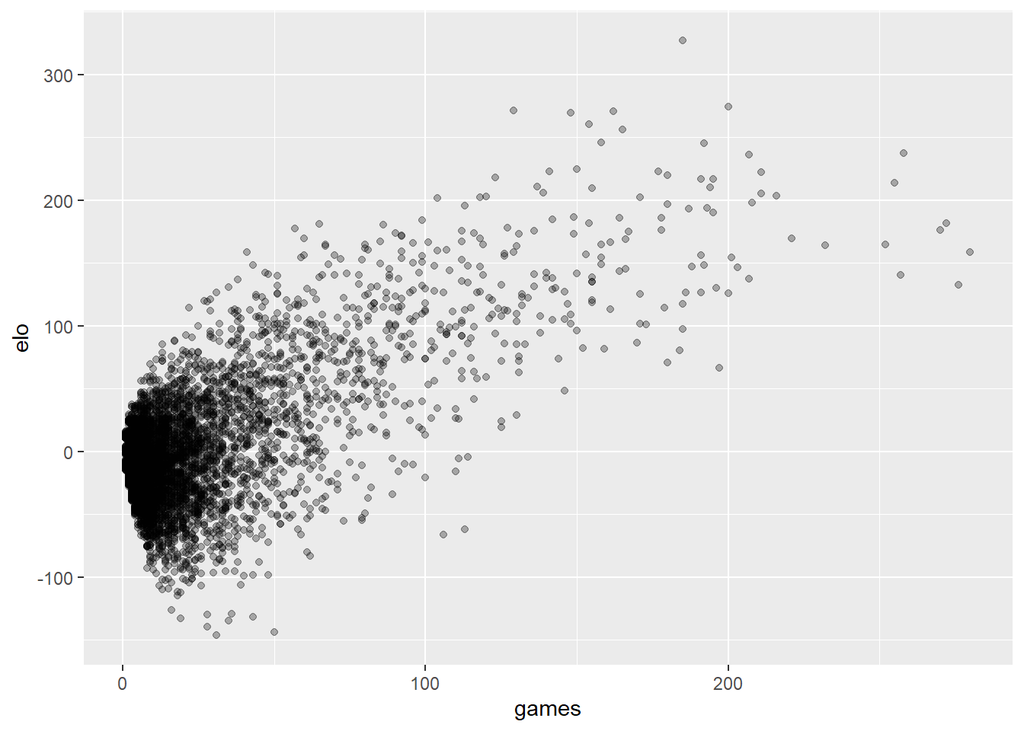

```r
ggplot(ratings, aes(games, elo)) +
  geom_point(alpha = 0.3)
```

The number of played games has a very strong effect on the point rating: points can only increase with games (a player never loses points), hence the more games a player plays, the more points it gains, almost linearly. The effect on the Elo rating is weaker: a player gains or loses rating according to its performance with respect to the expectation, and a player that performs as expected gains nothing regardless of the number of games played. In the scatterplot, players with the same number of games have very different Elo ratings, both positive and negative. The correlation is still positive because playing many games makes the Elo rating more extreme for players that are consistently stronger than their opponents (and the players with many games in this dataset tend to be strong players).